# Analyse univariée

### Variable 9 : Bonus malus

Ce score semble être une variable extrêment pertinente puisqu’il est directement lié à l’historique de sinistres du réclamant.

```r
MontantReclFr[bonus_malus < 50 | bonus_malus >= 350, ]$bonus_malus <- NA
```

#### Graphique

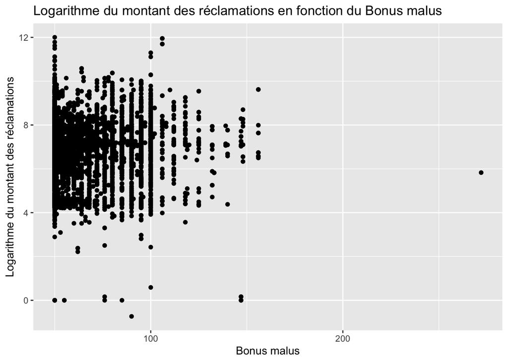

#### Statistiques

Moyenne

```
## [1] 68.48927
```

Médiane

```
## [1] 60
```

Écart-type

```
## [1] 20.82597
```

Minimum

[output not shown]

Maximum

```
## [1] 272
```

### Variable 10 : Type de garage

Puisque ce ne sont pas toutes les réclamations qui incluent cette information, nous convenons qu’elle semble moins pertinente pour le travail. Construisons toutefois un tableau de fréquence ainsi qu’un diagramme à mouches à titre d’information supplémentaire.

```r
table(garage)
```

```
## garage
##                aucun garage communautaire         garage prive
##                  705                  189                   99
```

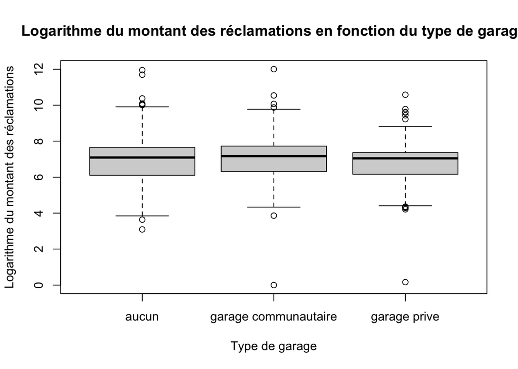

### Variable 11 : Source d’énergie

Cette variable peut présenter une multicolinéarité avec d’autres variables. Il faudra l’analyser plus en profondeur lors du choix du modèle. Puisque c’est une variable qualitative, construisons un tableau de fréquences ainsi qu’un diagramme à mouches.

```r
table(source_energ)
```

```
## source_energ
##     diesel electrique    regular
##       2152          3       4459
```

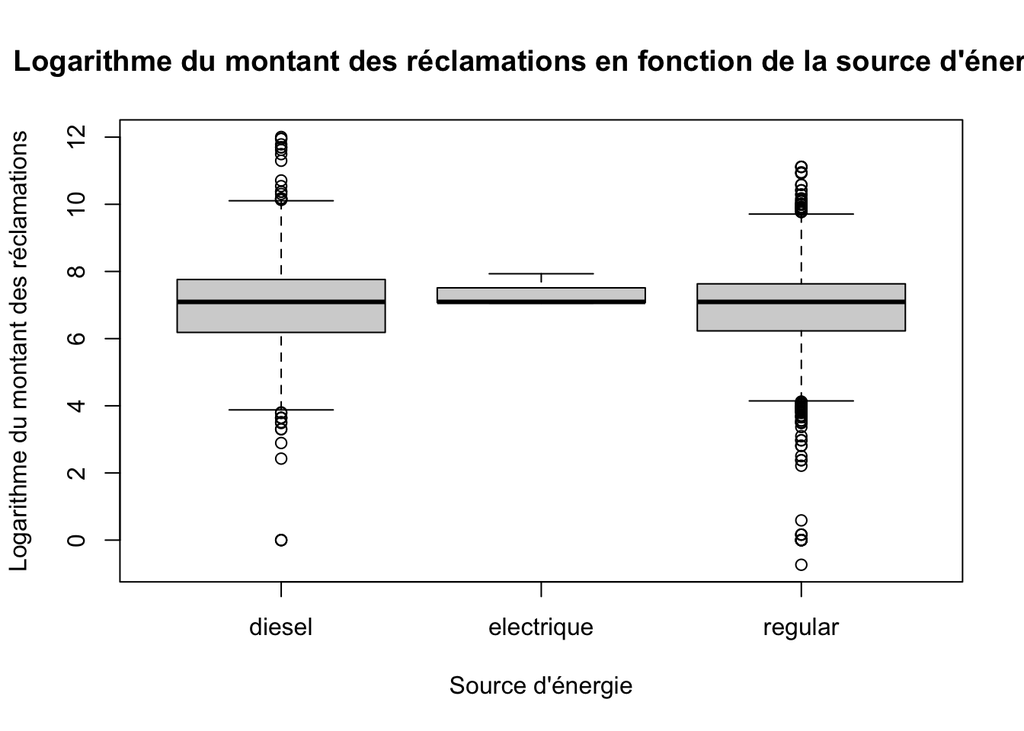

### Variable 12 : Valeur du véhicule

Cette valeur pourrait être très intéressante pour ce travail puisque la valeur du véhicule peu avoir un impact sur le montant de la réclamation.

#### Graphique

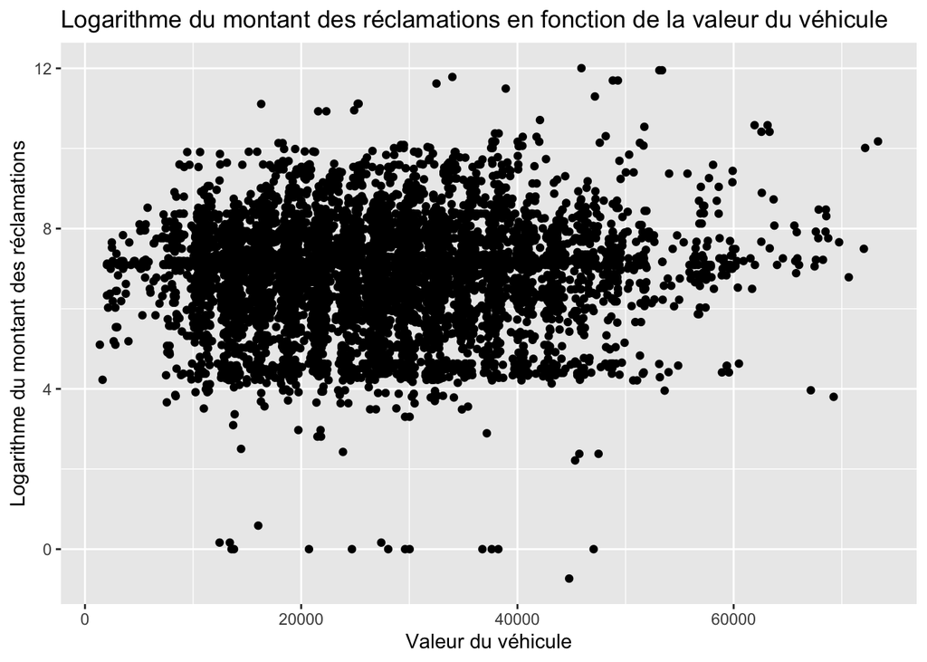

#### Statistique

Moyenne

```
## [1] 27155.64
```

Médiane

```
## [1] 26838.96
```

Écart-type

```
## [1] 11511.86
```

Minimum

```
## [1] 1373.976
```

Maximum

```
## [1] 73350.74
```